# Part II - Prosper Loan Data Exploration

## by Jesse Kimaru

## Investigation Overview

I wanted to investigate on how Prosper Credit handles its loan and how it evaluates its members before issuing any form of loan/credit.

## Dataset Overview

This data set contains information on peer to peer loans facilitated by credit company Prosper. There are 113,937 loans with 81 variables.

## Loan status

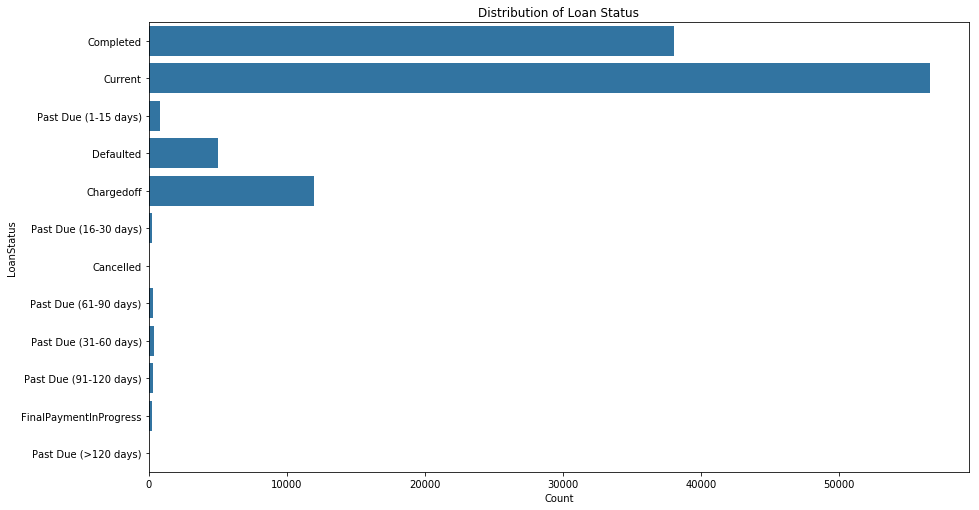

Majority of the members loan status is on current mode followed by the completed group. We can also observe that there are defaulted loans and a posibility of the number increasing due to some status being past due where the chargedoff has a quite high number of people coming in as the third largest group.

## What is the distribution of the Loan Amount?

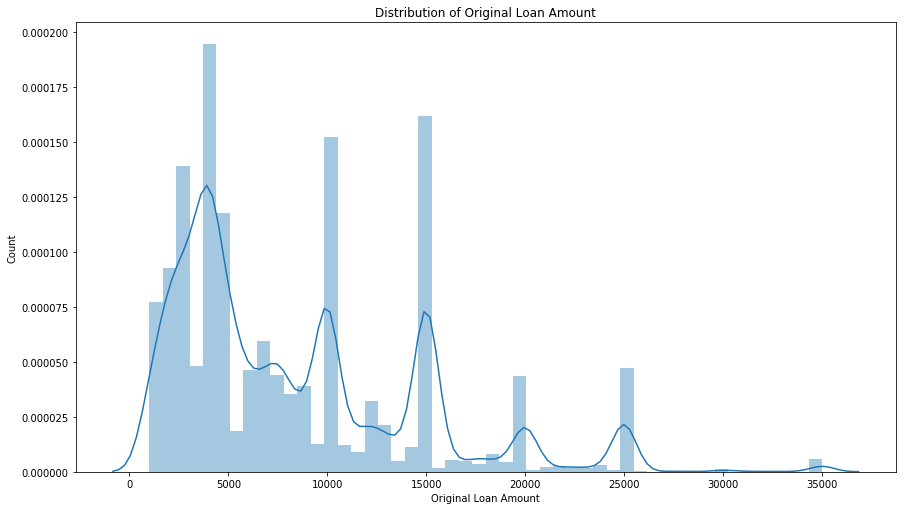

It is seen that loans between the bracket of 2000 to 10000 are popular, and those of between the range of 15000 upwards are not so popular.

## How much contribution do members make on Monthly Loan Payment?

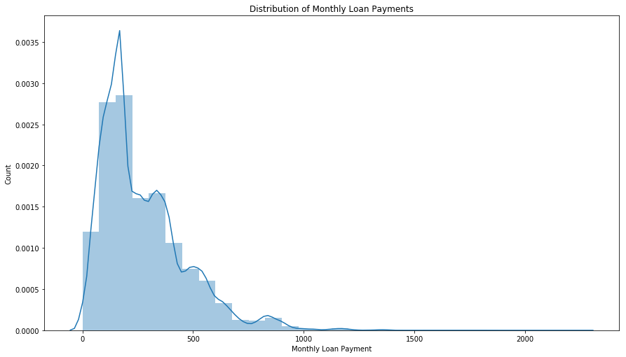

We can see that more than half of the borrowers make payments of less than 500 to service their loans on a monthly basis.

## Employment status

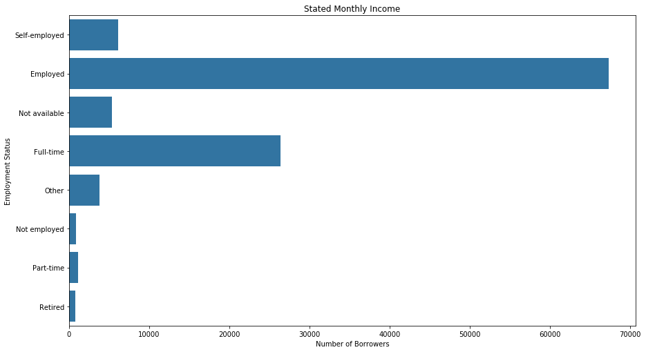

It is evident that the chances of geting a loan from Prosper one needs to be in employment, Either full-time, self-employed or any other form of employment.

## What is the relationship between Prosper Rating and Employment Status?

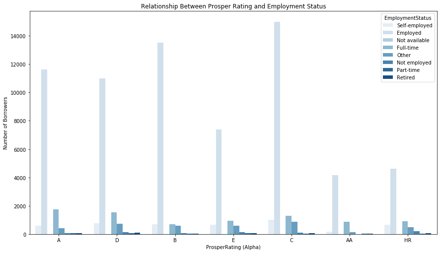

Category of members with lower rating is seen to be of Not Employed, Self-Employed, Retired and Part-Time employment status.

## Does Terms affect LoanOriginalAmount or StatedMonthlyIncome ?

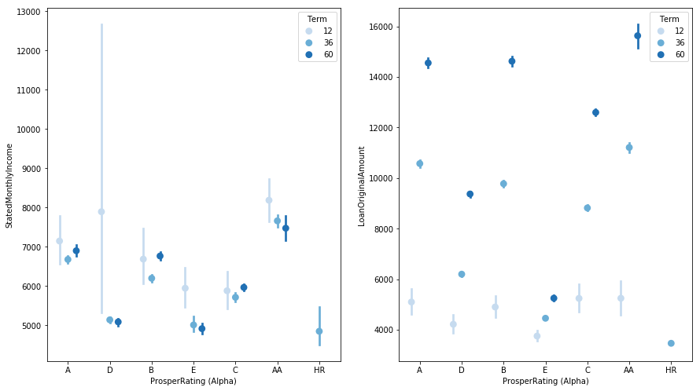

We can see that there is no effect between Terms and Ratings on Stated monthly income, but for loan amount, there is an effect on Terms and ratings since where the Prosper ratings are good the loan amounts of the three Terms increase progressively.